# Tria research qualifying paper - sample data

Richard Paquin Morel

1/30/2018

## Background and data

My dissertation uses data that I cannot publicly share. So I will use a publicly available set to demonstrate this code. The `ergm` pack has a number of sample social networks. First, load the relevant libraries.

I will use the “faux.desert.high” network, which approximates the structure the network used for my study. It is directed, has 107 nodes (compared to 84) and a density of 0.04 (compared to 0.07)

```r
data("faux.desert.high")
summary(faux.desert.high, print.adj = FALSE)
```

```
## Network attributes:
##   vertices = 107
##   directed = TRUE
##   hyper = FALSE
##   loops = FALSE
##   multiple = FALSE
##   bipartite = FALSE
##   title = comm6.net
##  total edges = 439
##    missing edges = 0
##    non-missing edges = 439
##  density = 0.0387057
##
## Vertex attributes:
##
##  grade:
##    integer valued attribute
##    107 values
##
##  race:
##    character valued attribute
##    attribute summary:
##  A  B  H  O  W
##  1  2  3  7 94
##
##  scode:
##    integer valued attribute
##    107 values
##
##  sex:
##    integer valued attribute
##    107 values
##   vertex.names:
##    character valued attribute
##    107 valid vertex names
##
## No edge attributes
```

Let’s take a quick look at the networks, using the [`ggraph` package](https://github.com/thomasp85/ggraph). `ggraph` is rapidly becoming my go-to for network visualization. It’s clean, intuitive, and based on `ggplot2`.

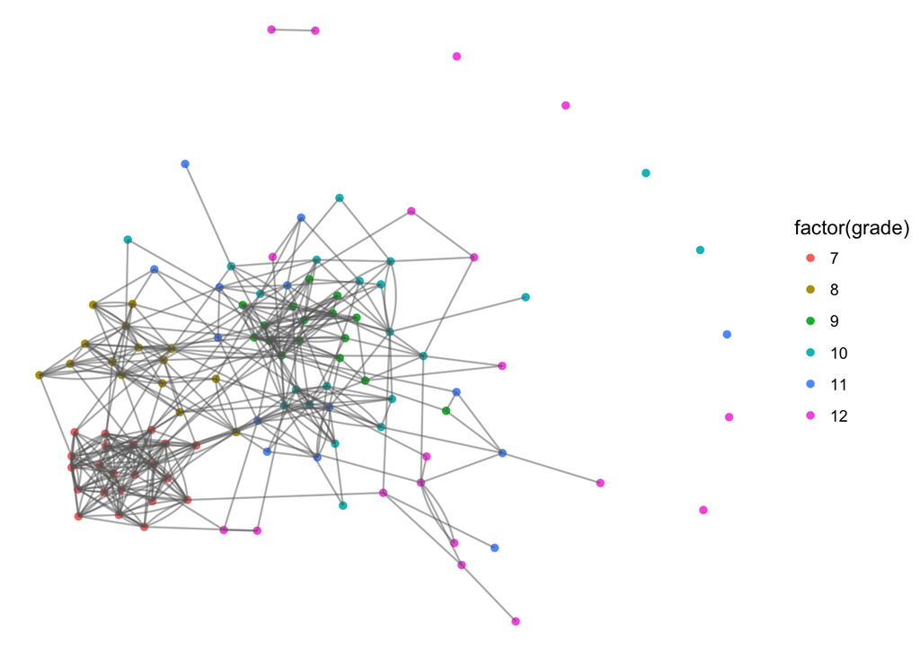

```r
ggraph(faux.desert.high) +
  geom_node_point(aes(colour = factor(grade))) +
  geom_edge_fan(colour = "grey40", alpha = 0.5) +
  theme_void()
```

## Brokerage and model specification

My study explores inter- and intra-organization brokering. For this network, I will use grade as the grouping variable for measuring brokerage. The measure of brokerage I use comes from Gould and Fernandez’s seminal 1989 paper in *Sociological Methododology*. The `brokerage` function yields several measures – I only want the raw brokerage scores. This score is a count of the number of times a node mediates between two otherwise unconnected nodes.

```r
brkrg <- brokerage(faux.desert.high, faux.desert.high %v% "grade")$raw.nli
head(brkrg)
```

```
##   w_I w_O b_IO b_OI b_O  t
## 1   1   0    1    5   1  8
## 2   0   0    0    0   0  0
## 3   4   0    3    8   3 18
## 4   0   0    0    1   1  2
## 5   0   0    0    0   0  0
## 6   0   0    0    0   0  0
```

This takes a while.

```r
model <- ergm(faux.desert.high ~ edges + mutual +
                    intransitive +
                    gwesp(0.1, T) +
                    gwdsp(0.1, T) +
                    nodematch("grade"))

summary(model)
```

```
##
## ==========================
## Summary of model fit
## ==========================
##
## Formula:   faux.desert.high ~ edges + mutual + intransitive + gwesp(0.1,
##     T) + gwdsp(0.1, T) + nodematch("grade")
##
## Iterations:  2 out of 20
##
## Monte Carlo MLE Results:
##                 Estimate Std. Error MCMC % p-value
## edges           -4.56642    0.16753      0 < 1e-04 ***
## mutual           1.73139    0.20062      0 < 1e-04 ***
## intransitive     0.04752    0.01241      1 0.00013 ***
## gwesp.fixed.0.1  1.21804    0.10549      0 < 1e-04 ***
## gwdsp.fixed.0.1 -0.09799    0.02236      0 < 1e-04 ***
## nodematch.grade  1.29611    0.11547      0 < 1e-04 ***
## ---
## Signif. codes:  0 '***' 0.001 '**' 0.01 '*' 0.05 '.' 0.1 ' ' 1
##
##      Null Deviance: 15723  on 11342  degrees of freedom
##  Residual Deviance:  2624  on 11336  degrees of freedom
##
## AIC: 2636    BIC: 2680    (Smaller is better.)
```

After specifying and estimating the model, it is critical to assess its fit to the data and to diagnose any issues in the Markov Chain Monte Carlo simulation.

First, let’s make sure the model parameters does a good job capturing observed network.

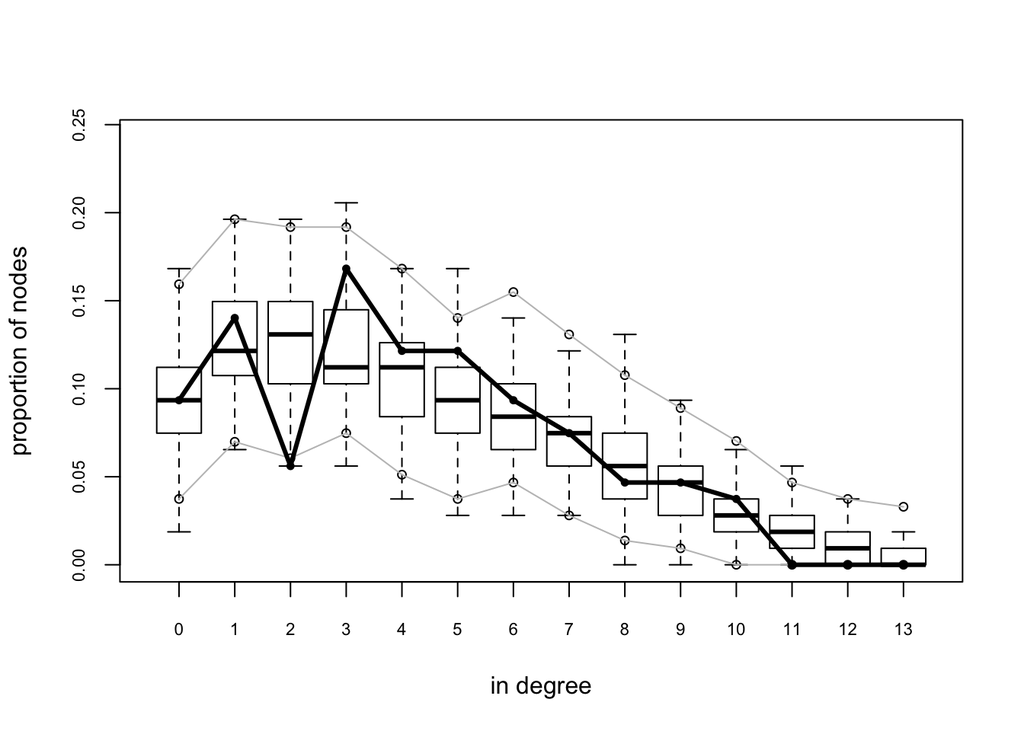

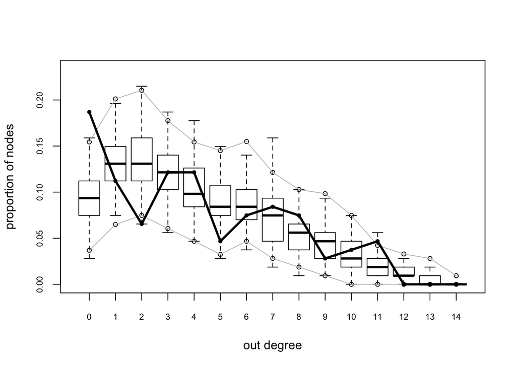

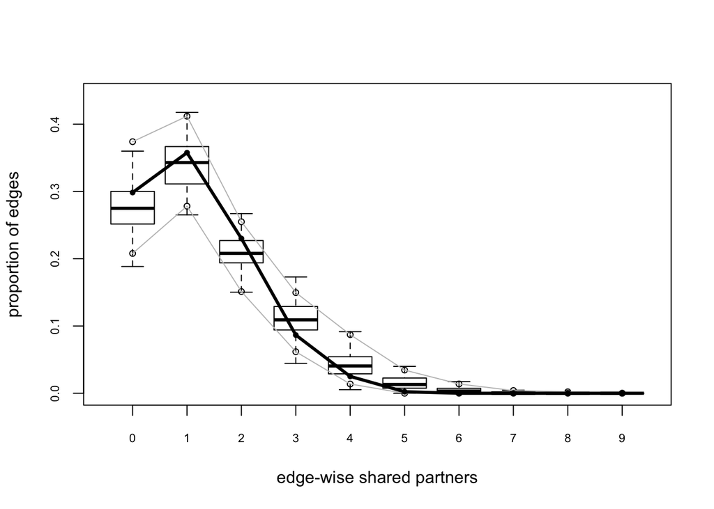

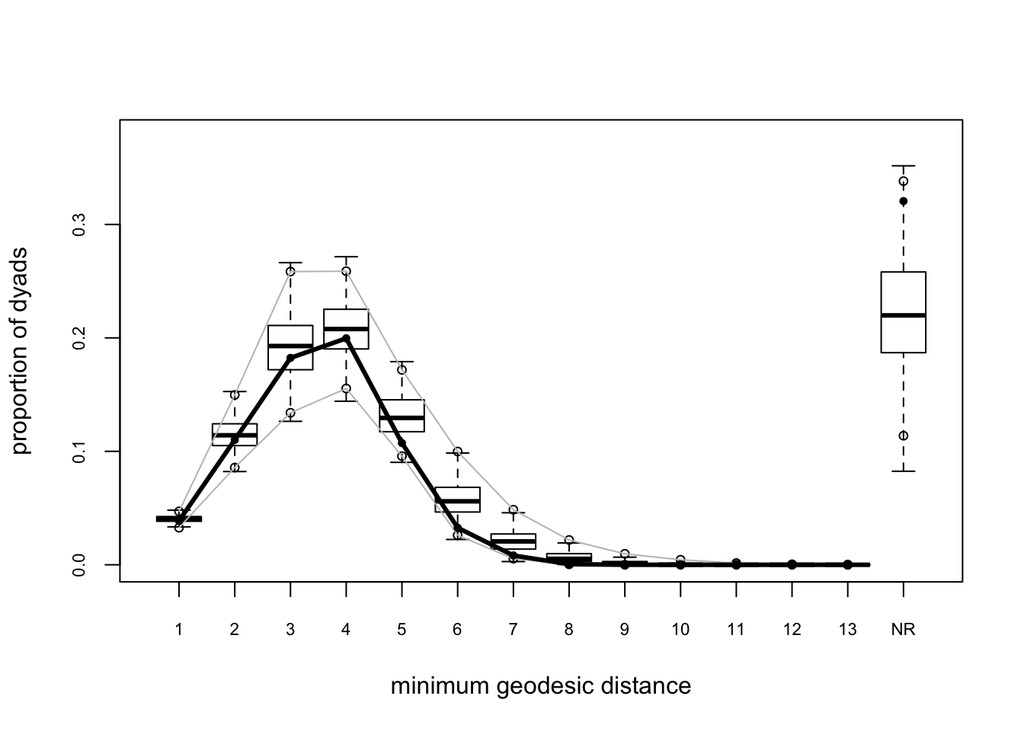

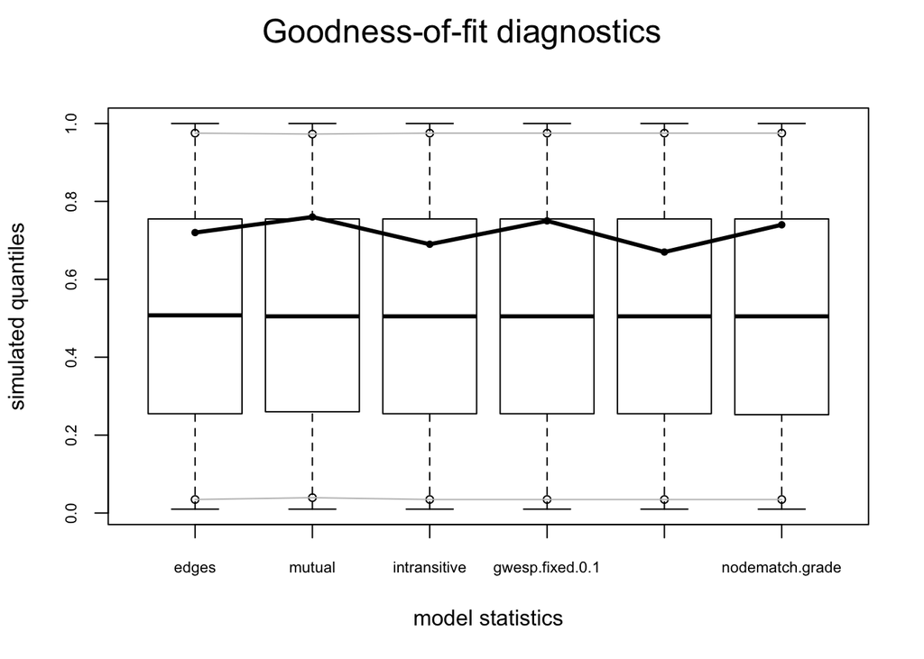

```r
model_gof <- gof(model)
plot(model_gof)
```

This assessment is insufficient in itself (see Hunter, D. R., Goodreau, S. M., & Handcock, M. S. (2008). Goodness of Fit of Social Network Models. Journal of the American Statistical Association, 103(481), 248–258). The model should also do a good job capturing network statistics *not* included in the model.

To do this, we need to simulate some networks based on the parameters in the model, derive distributions of network statistics, and compare them the to observed statistics. We need these simulated networks for the main analysis anyway. Let’s compared the number of triangles in the observed and simulated networks.

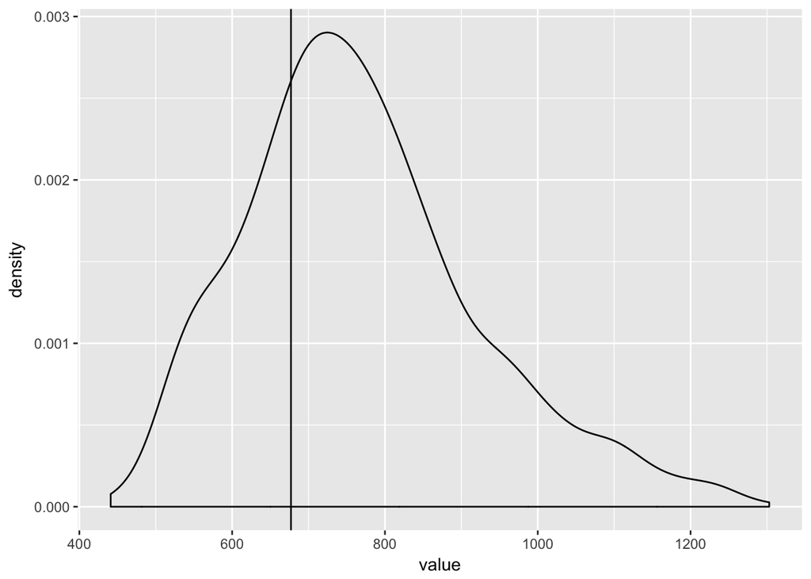

```r
model_sim <- simulate(model,
                      nsim = 1000,
                      seed = 47,
                      basis = faux.desert.high)

model_tridist <- map_dbl(model_sim, ~ summary(. ~ triangle))
model_tridist %>%
  as_data_frame() %>%
  ggplot() +
  geom_density(aes(x = value)) +
  geom_vline(xintercept = summary(faux.desert.high ~ triangle))
```

Ok, not too bad. Let’s see where the observed value falls in the distribution.

```r
ecdf(model_tridist)(summary(faux.desert.high ~ triangle))
```

```
## [1] 0.284
```

Now I can proceed with the brokerage test. Here’s the basic process:

1. Specify an exponential random graph model to form the baseline. (Done.)
2. Evaluate the model fit to the data. (Done.)
3. Simulate 1000 networks using the estimated parameters. (Done.)
4. Derive brokerage scores for each node in each simulated network.
5. Randomly sample 1000 scores per role per grade.
6. Compare the observed scores for each node to the conditional distribution. 95th percentile or higher, I consider a broker.

I condition the distribution on grade-level for a couple reason. First, we probably expect the dynamics of brokerage are different for freshman and seniors. Freshman are the lowest on the social hierarchy and so probably have fewer brokerage opporunities. Second, it is necessary to condition on the size of the grade, since the measure of brokerage is a count. Fewer people, fewer opportunities for brokerage. Gould and Fernandez condition on group size in their paper.

```r
brkrg_sim <- map(model_sim, ~brokerage(., . %v% "grade")) %>%
  map(`[[`, "raw.nli") %>%
  map(as_data_frame) %>%
  map(., ~ mutate(., grade = faux.desert.high %v% "grade")) %>%
  bind_rows(.)
```

```r
dist <- brkrg_sim %>%
  group_by(grade) %>%
  sample_n(1000) %>%
  split(., .$grade)

obs <- brkrg %>%
  as_data_frame() %>%
  mutate(grade = faux.desert.high %v% "grade",
         id = faux.desert.high %v% "vertex.names") %>%
  split(., .$grade)
```

I have two lists of data frames. One, `dist`, consists of simulated brokerage scores for each grade. The other, `obs`, consists of the observed brokerage scores by grade. Let’s look.

```r
head(dist[[1]])
```

```
## # A tibble: 6 x 7
## # Groups: grade [1]
##     w_I   w_O  b_IO  b_OI   b_O      t grade
##   <dbl> <dbl> <dbl> <dbl> <dbl>  <dbl> <int>
## 1  5.00     0     0  3.00  0      8.00     7
## 2  0        0     0  3.00  1.00   4.00     7
## 3 18.0      0     0  5.00  0     23.0      7
## 4  0        0     0  0     0      0        7
## 5 44.0      0     0  0     0     44.0      7
## 6 84.0      0     0 19.0   0    103        7
```

```r
head(obs[[1]])
```

```
## # A tibble: 6 x 8
##     w_I   w_O  b_IO  b_OI   b_O     t grade id
##   <dbl> <dbl> <dbl> <dbl> <dbl> <dbl> <int> <chr>
## 1 44.0      0 14.0   0     0     58.0     7 7
## 2 34.0      0 13.0   0     0     47.0     7 12
## 3 20.0      0  0     6.00  0     26.0     7 15
## 4  9.00     0  3.00  6.00  1.00  19.0     7 19
## 5 11.0      0  0     0     0     11.0     7 24
## 6 29.0      0 16.0   5.00  0     50.0     7 34
```

Let’s continue to explore by comparing some observed scores to the simulated distributions.

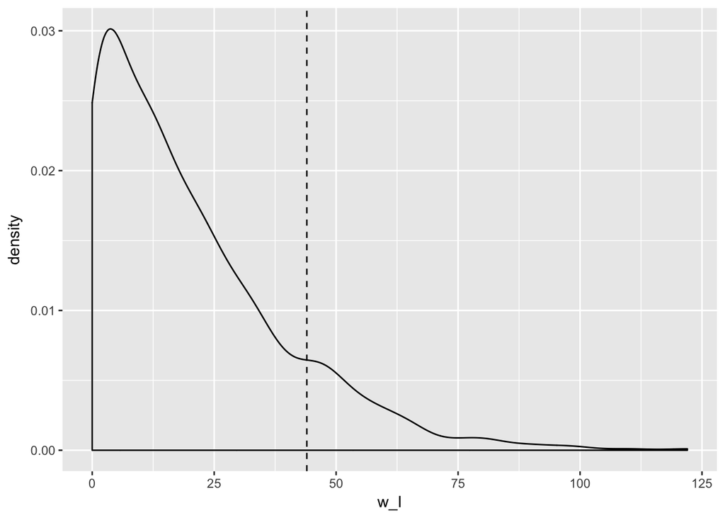

```r
set.seed(83)
t <- obs[[1]] %>% select(w_I) %>% sample_n(1) %>% pull()

ggplot(dist[[1]]) +
  geom_density(aes(x = w_I)) +
  geom_vline(xintercept = t, linetype = 2)
```

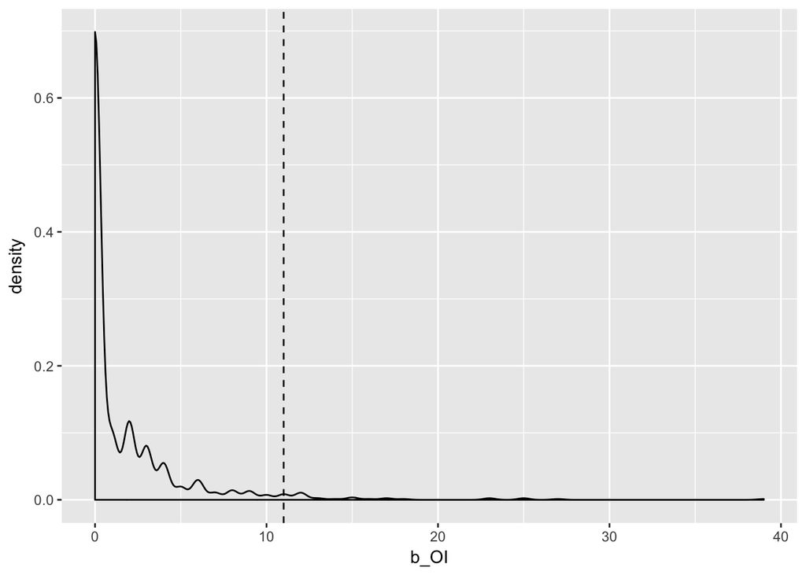

```r
set.seed(35)
t <- obs[[3]] %>% select(b_OI) %>% sample_n(1) %>% pull()

ggplot(dist[[3]]) +
  geom_density(aes(x = b_OI)) +
  geom_vline(xintercept = t, linetype = 2)
```

To test incidence of brokerage, I need to compare each node’s score for each brokerage role to the simulated distributions – all of this conditioning on grade level. The code below is not pretty but gets the job done.

```r
w_I <- list()
for (i in 1:length(dist)){
  w_I[[i]] <- map_dbl(1:nrow(obs[[i]]), function(x) mean(dist[[i]]$w_I >= obs[[i]]$w_I[x]))
}
w_O <- list()
for (i in 1:length(dist)){
  w_O[[i]] <- map_dbl(1:nrow(obs[[i]]), function(x) mean(dist[[i]]$w_O >= obs[[i]]$w_O[x]))
}
b_IO <- list()
for (i in 1:length(dist)){
  b_IO[[i]] <- map_dbl(1:nrow(obs[[i]]), function(x) mean(dist[[i]]$b_IO >= obs[[i]]$b_IO[x]))
}
b_OI <- list()
for (i in 1:length(dist)){
  b_OI[[i]] <- map_dbl(1:nrow(obs[[i]]), function(x) mean(dist[[i]]$b_OI >= obs[[i]]$b_OI[x]))
}
b_O <- list()
for (i in 1:length(dist)){
  b_O[[i]] <- map_dbl(1:nrow(obs[[i]]), function(x) mean(dist[[i]]$b_O >= obs[[i]]$b_O[x]))
}
t <- list()
for (i in 1:length(dist)){
  t[[i]] <- map_dbl(1:nrow(obs[[i]]), function(x) mean(dist[[i]]$t >= obs[[i]]$t[x]))
}

b_scores <- data.frame(Name = bind_rows(obs)[,"id"],
                       Coordinator = unlist(w_I),
                       Consultant = unlist(w_O),
                       Representative = unlist(b_IO),
                       Gatekeeper = unlist(b_OI),
                       Liaison = unlist(b_O),
                       Total = unlist(t),
                       stringsAsFactors = F)

head(b_scores)
```

```
##   id Coordinator Consultant Representative Gatekeeper Liaison Total
## 1  7       0.129          1          0.119      1.000   1.000 0.152
## 2 12       0.195          1          0.133      1.000   1.000 0.235
## 3 15       0.402          1          1.000      0.377   1.000 0.494
## 4 19       0.655          1          0.561      0.377   0.374 0.620
## 5 24       0.612          1          1.000      1.000   1.000 0.749
## 6 34       0.262          1          0.091      0.435   1.000 0.216
```

So those are all percentile ranks for each node’s brokerage score in each role. We have to choose an alpha as the cutoff for significance. I used 0.05 in my paper, but I could see an argument for 0.01. I will create a dummy variable for each row where 1 indicate the node occupies a brokerage role and 0 otherwise.

```r
brokers <- b_scores %>%
  mutate_at(vars(Coordinator:Total), funs(if_else(. <= 0.01, 1, 0))) %>%
  transmute(id = as.numeric(id),
            broker = if_else(rowSums(select(., Coordinator:Total)) == 0, 0, 1)) %>%
  arrange(id)

faux.desert.high %v% "broker" <- brokers$broker
```

Let’s take a look at here those brokers are. I’m going to increase the size of broker nodes so that they are easy to spot.

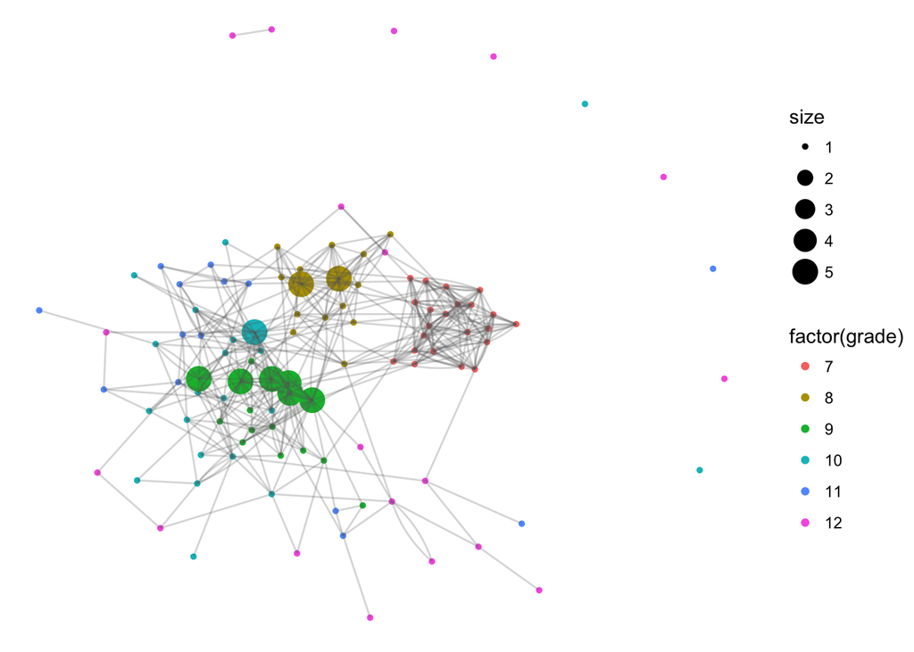

```r
faux.desert.high %v% "size" <- if_else(faux.desert.high %v% "broker" == 1, 5, 1)

ggraph(faux.desert.high) +
  geom_node_point(aes(colour = factor(grade), size = size)) +
  geom_edge_fan(colour = "grey40", alpha = 0.25) +
  theme_void()
```

As suspected, most of the brokering activities occur in the middle grades – the high schoolers who probably have the most incentive to form friendships across grades. The seventh graders are new and so stick together; the seniors are pretty much checked out. This make me curious about how heterogeneous the ego networks of the brokers are. I like the *network range* algorithm developed by Burt (1982) and used by nicely by Reagans and McEvily (2002). It is a measure of the divserity of an actor’s network ties. [I coded the algorithm in R myself](https://github.com/ramorel/network-range), since none of the network packages in R have it baked in. It’s a bit of an obscure measure, so that’s probably why. I give a more detailed explanation in the [README](https://github.com/ramorel/network-range/blob/master/README.md) for the repository. Put succinctly – an ego’s network range increases under two conditions: (1) the more ties they have to others in different groups; and (2) the extent to which the individuals in those groups are loosely connected. An ego network with a lot of range is one where an actor has connections to many groups that are loosely connected.

I’ll import the function (called `netrange`) from GitHub.

The function has three arguments: network, attr (the grouping variable) and directed (which defaults to TRUE). `NaN` is returned for isolates. The scores range from 0 to 1, with 1 indicating the most diversity.

```r
brokers <- brokers %>%
  mutate(range = netrange(faux.desert.high, faux.desert.high %v% "grade"))

head(brokers)
```

```
##   id broker     range
## 1  1      0 0.6846497
## 2  2      0       NaN
## 3  3      0 0.5246731
## 4  4      0 0.7298701
## 5  5      0 0.4000000
## 6  6      0 0.4000000
```

Let’s compare the brokers and non-brokers on range scores.

```r
brokers %>%
  group_by(broker) %>%
  summarize(mean_range = mean(range, na.rm = T),
            sd_range = sd(range, na.rm = T))
```

```
## # A tibble: 2 x 3
##   broker mean_range sd_range
##    <dbl>      <dbl>    <dbl>
## 1   0         0.457    0.230
## 2   1.00      0.598    0.230
```

Indeed the brokers have greater mean range scores.